# Chapter 1

Brian J. Knaus

7/14/2017

## 1.1 A simple example of random effects

```r
library(nlme)
head(Rail)
```

```
## Grouped Data: travel ~ 1 | Rail
##   Rail travel
## 1    1     55
## 2    1     53
## 3    1     54
## 4    2     26
## 5    2     37
## 6    2     32
```

```r
class(Rail)
```

```
## [1] "nffGroupedData" "nfGroupedData"  "groupedData"    "data.frame"
```

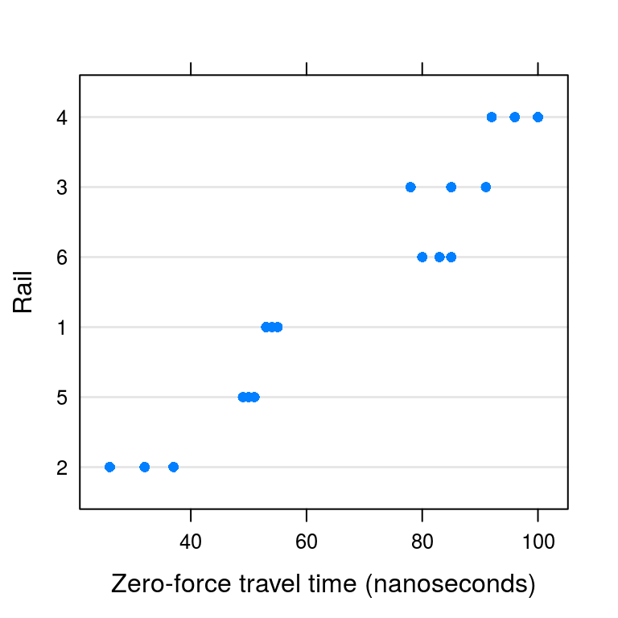

```r
plot(Rail)
```

We see that the data are in a `data.frame`-like object that appears tabular. The `plot` method reproduces the figure from the book and shows that our dataset consists of 6 rails that have each been tested 3 times.

Our first attempt to characterize the data ignores any grouping information. Mathematically it is expressed as follows.

$$y_{ij} = \beta + \epsilon_{ij},\\
i = 1, ..., M, \\
j = 1, ..., n_{i}. (1.1)$$

Here $M$ iterates over rails, $j$ iterates over observations for each rail, $n_{i}$ is the number of observations for each rail, $y$ is our response (travel), $\beta$ is tha parameter we’d like to infer and $\epsilon$ is the normally distributed error term. In R we express this with a model formula.

```r
fm1Rail.lm <- lm(travel ~ 1, data = Rail)
summary(fm1Rail.lm)
```

```
##
## Call:
## lm(formula = travel ~ 1, data = Rail)
##
## Residuals:
##    Min     1Q Median     3Q    Max
## -40.50 -16.25   0.00  18.50  33.50
##
## Coefficients:
##             Estimate Std. Error t value Pr(>|t|)
## (Intercept)   66.500      5.573   11.93  1.1e-09 ***
## ---
## Signif. codes:  0 '***' 0.001 '**' 0.01 '*' 0.05 '.' 0.1 ' ' 1
##
## Residual standard error: 23.65 on 17 degrees of freedom
```

The model only asks to inferr the intercept (indicates by `~ 1`). This is analagous to taking a simple mean: 66.5. The variation we observe around this mean is 23.65 which, as pointed out in the book, is substantial.

We build a slightly more complex model by adding ‘rail effects’ as a ‘fixed effect.’ Mathematically we express this as follows.

$$y_{ij} = \beta_{i} + \epsilon_{ij},\\
i = 1, ..., M, \\
j = 1, ..., n_{i}. (1.2)$$

Note that our parameter $\beta$ now has a counter.

The model formula for fitting this model in R is below.

```r
fm2Rail.lm <- lm(travel ~ Rail - 1, data = Rail)
summary(fm2Rail.lm)
```

```
##
## Call:
## lm(formula = travel ~ Rail - 1, data = Rail)
##
## Residuals:
##     Min      1Q  Median      3Q     Max
## -6.6667 -1.0000  0.1667  1.0000  6.3333
##
## Coefficients:
##       Estimate Std. Error t value Pr(>|t|)
## Rail2   31.667      2.321   13.64 1.15e-08 ***
## Rail5   50.000      2.321   21.54 5.86e-11 ***
## Rail1   54.000      2.321   23.26 2.37e-11 ***
## Rail6   82.667      2.321   35.61 1.54e-13 ***
## Rail3   84.667      2.321   36.47 1.16e-13 ***
## Rail4   96.000      2.321   41.35 2.59e-14 ***
## ---
## Signif. codes:  0 '***' 0.001 '**' 0.01 '*' 0.05 '.' 0.1 ' ' 1
##
## Residual standard error: 4.021 on 12 degrees of freedom
## Multiple R-squared:  0.9978, Adjusted R-squared:  0.9967
## F-statistic: 916.6 on 6 and 12 DF,  p-value: 2.971e-15
```

We now have a mean for each rail. These values can be compared to the plot above.

A random effects model would be as follows.

$$y_{ij} = \beta + b_{i} + \epsilon_{ij}, (1.4)\\$$

Here, $\beta$ is the mean travel time across the population of rails and $b_{i}$ is a random variable representing the deviation from the population mean of the mean travel time for the $i$th rail. We now have two random variables.

$$b_{i} \sim N(0, \sigma^{2}_{b}), \epsilon \sim N(0, \sigma^{2}). (1.5)$$

### 1.1.1 Fitting the random-effects model with lme

```r
fm1Rail.lme <- lme(travel ~ 1, data = Rail, random = ~ 1 | Rail)
summary(fm1Rail.lme)
```

```
## Linear mixed-effects model fit by REML
##  Data: Rail
##       AIC      BIC   logLik
##   128.177 130.6766 -61.0885
##
## Random effects:
##  Formula: ~1 | Rail
##         (Intercept) Residual
## StdDev:    24.80547 4.020779
##
## Fixed effects: travel ~ 1
##             Value Std.Error DF  t-value p-value
## (Intercept)  66.5  10.17104 12 6.538173       0
##
## Standardized Within-Group Residuals:
##         Min          Q1         Med          Q3         Max
## -1.61882658 -0.28217671  0.03569328  0.21955784  1.61437744
##
## Number of Observations: 18
## Number of Groups: 6
```

```r
fm1Rail.lmeML <- update(fm1Rail.lme, method = "ML")
summary(fm1Rail.lmeML)
```

```
## Linear mixed-effects model fit by maximum likelihood
##  Data: Rail
##      AIC      BIC    logLik
##   134.56 137.2312 -64.28002
##
## Random effects:
##  Formula: ~1 | Rail
##         (Intercept) Residual
## StdDev:    22.62435 4.020779
##
## Fixed effects: travel ~ 1
##             Value Std.Error DF  t-value p-value
## (Intercept)  66.5  9.554026 12 6.960417       0
##
## Standardized Within-Group Residuals:
##         Min          Q1         Med          Q3         Max
## -1.61098123 -0.28887045  0.03454166  0.21372780  1.62222279
##
## Number of Observations: 18
## Number of Groups: 6
```

### 1.1.2 Assessing the fitted model

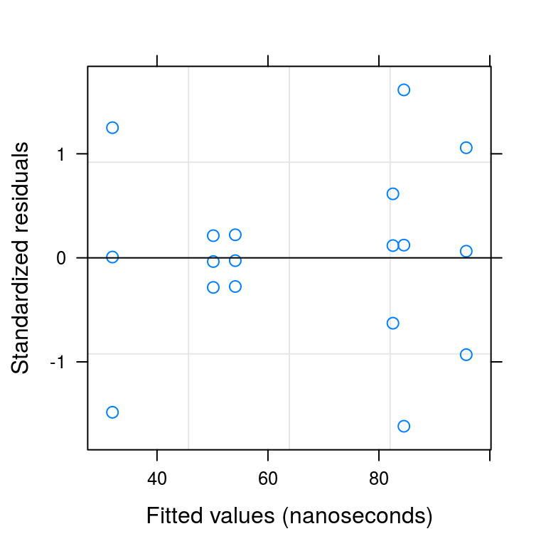

```r
plot(fm1Rail.lme)
```

```r
intervals(fm1Rail.lme)
```

```
## Approximate 95% confidence intervals
##
##  Fixed effects:
##                lower est.    upper
## (Intercept) 44.33921 66.5 88.66079
## attr(,"label")
## [1] "Fixed effects:"
##
##  Random Effects:
##   Level: Rail
##                    lower     est.    upper
## sd((Intercept)) 13.27434 24.80547 46.35341
##
##  Within-group standard error:
##    lower     est.    upper
## 2.695007 4.020779 5.998747
```

```r
anova(fm1Rail.lme)
```

```
##             numDF denDF F-value p-value
## (Intercept)     1    12 42.7477  <.0001
```

## 1.2 A randomized block design

A randomized block experiment has two classification factors: an experimental factor where we’ll use ‘fixed effects’ and blocking factor where we’ll use ‘random effects.’ In the ergoStool example there are four types of stool that we wish to make inferences about, so we use fixed effects. There are 9 subjects that measured the stools represent a sample from a population which we would like to make inferences about so we use random effects to model them.

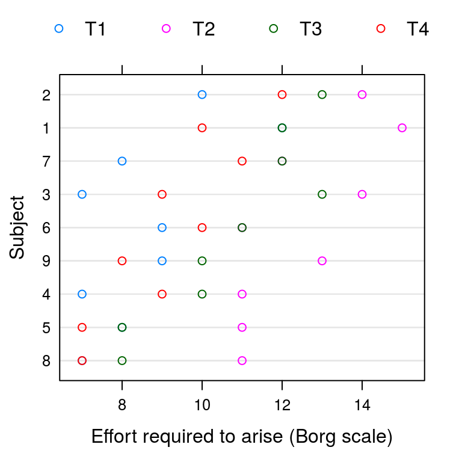

```r
plot(ergoStool)
```

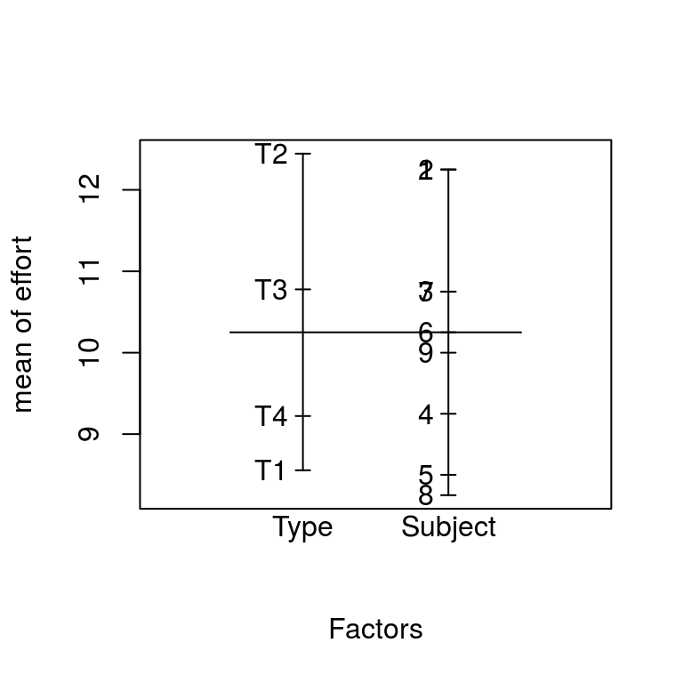

```r
plot.design(ergoStool)
```

## 1.2 Choosing contrasts for fixed-effects terms

Our model for our randomized block design can be expressed mathematically.

$$y_{ij} = \beta_{j} + b_{i} + \epsilon_{ij}, i = 1, ..., 9, j = 1, ..., 4\\
b_{i} \sim N(0,\sigma^{2}_{b}), \epsilon \sim N(0, \sigma^{2})(1.6)$$

```r
#options( contrasts = c(factor = "contr.treatment", ordered = "contr.poly"))
options( contrasts = c(factor = "contr.helmert", ordered = "contr.poly"))
contrasts(ergoStool$Type)
```

```
##    [,1] [,2] [,3]
## T1   -1   -1   -1
## T2    1   -1   -1
## T3    0    2   -1
## T4    0    0    3
```

```r
ergoStool1 <- ergoStool[ ergoStool$Subject == "1", ]
model.matrix( effort ~ Type, ergoStool1)
```

```
##   (Intercept) Type1 Type2 Type3
## 1           1    -1    -1    -1
## 2           1     1    -1    -1
## 3           1     0     2    -1
## 4           1     0     0     3
## attr(,"assign")
## [1] 0 1 1 1
## attr(,"contrasts")
## attr(,"contrasts")$Type
## [1] "contr.helmert"
```

```r
fm1Stool <- lme(effort ~ Type, data = ergoStool, random = ~ 1 | Subject)
summary(fm1Stool)
```

```
## Linear mixed-effects model fit by REML
##  Data: ergoStool
##        AIC      BIC    logLik
##   139.4869 148.2813 -63.74345
##
## Random effects:
##  Formula: ~1 | Subject
##         (Intercept) Residual
## StdDev:    1.332465 1.100295
##
## Fixed effects: effort ~ Type
##                 Value Std.Error DF   t-value p-value
## (Intercept) 10.250000 0.4805234 24 21.330905  0.0000
## Type1        1.944444 0.2593419 24  7.497610  0.0000
## Type2        0.092593 0.1497311 24  0.618392  0.5421
## Type3       -0.342593 0.1058759 24 -3.235794  0.0035
##  Correlation:
##       (Intr) Type1 Type2
## Type1 0
## Type2 0      0
## Type3 0      0     0
##
## Standardized Within-Group Residuals:
##         Min          Q1         Med          Q3         Max
## -1.80200345 -0.64316591  0.05783115  0.70099706  1.63142054
##
## Number of Observations: 36
## Number of Groups: 9
```

```r
anova(fm1Stool)
```

```
##             numDF denDF  F-value p-value
## (Intercept)     1    24 455.0075  <.0001
## Type            3    24  22.3556  <.0001
```

```r
options( contrasts = c(factor = "contr.treatment", ordered = "contr.poly"))
#options( contrasts = c(factor = "contr.helmert", ordered = "contr.poly"))
contrasts(ergoStool$Type)
```

```
##    T2 T3 T4
## T1  0  0  0
## T2  1  0  0
## T3  0  1  0
## T4  0  0  1
```

```r
fm2Stool <- lme(effort ~ Type, data = ergoStool, random = ~ 1 | Subject)
summary(fm2Stool)
```

```
## Linear mixed-effects model fit by REML
##  Data: ergoStool
##        AIC      BIC    logLik
##   133.1308 141.9252 -60.56539
##
## Random effects:
##  Formula: ~1 | Subject
##         (Intercept) Residual
## StdDev:    1.332465 1.100295
##
## Fixed effects: effort ~ Type
##                Value Std.Error DF   t-value p-value
## (Intercept) 8.555556 0.5760123 24 14.853079  0.0000
## TypeT2      3.888889 0.5186838 24  7.497610  0.0000
## TypeT3      2.222222 0.5186838 24  4.284348  0.0003
## TypeT4      0.666667 0.5186838 24  1.285304  0.2110
##  Correlation:
##        (Intr) TypeT2 TypeT3
## TypeT2 -0.45
## TypeT3 -0.45   0.50
## TypeT4 -0.45   0.50   0.50
##
## Standardized Within-Group Residuals:
##         Min          Q1         Med          Q3         Max
## -1.80200345 -0.64316591  0.05783115  0.70099706  1.63142054
##
## Number of Observations: 36
## Number of Groups: 9
```

```r
anova(fm2Stool)
```

```
##             numDF denDF  F-value p-value
## (Intercept)     1    24 455.0075  <.0001
## Type            3    24  22.3556  <.0001
```

```r
model.matrix( effort ~ Type - 1, ergoStool1 )
```

```
##   TypeT1 TypeT2 TypeT3 TypeT4
## 1      1      0      0      0
## 2      0      1      0      0
## 3      0      0      1      0
## 4      0      0      0      1
## attr(,"assign")
## [1] 1 1 1 1
## attr(,"contrasts")
## attr(,"contrasts")$Type
## [1] "contr.treatment"
```

```r
fm3Stool <- lme(effort ~ Type, data = ergoStool, random = ~ 1 | Subject)
summary(fm3Stool)
```

```
## Linear mixed-effects model fit by REML
##  Data: ergoStool
##        AIC      BIC    logLik
##   133.1308 141.9252 -60.56539
##
## Random effects:
##  Formula: ~1 | Subject
##         (Intercept) Residual
## StdDev:    1.332465 1.100295
##
## Fixed effects: effort ~ Type
##                Value Std.Error DF   t-value p-value
## (Intercept) 8.555556 0.5760123 24 14.853079  0.0000
## TypeT2      3.888889 0.5186838 24  7.497610  0.0000
## TypeT3      2.222222 0.5186838 24  4.284348  0.0003
## TypeT4      0.666667 0.5186838 24  1.285304  0.2110
##  Correlation:
##        (Intr) TypeT2 TypeT3
## TypeT2 -0.45
## TypeT3 -0.45   0.50
## TypeT4 -0.45   0.50   0.50
##
## Standardized Within-Group Residuals:
##         Min          Q1         Med          Q3         Max
## -1.80200345 -0.64316591  0.05783115  0.70099706  1.63142054
##
## Number of Observations: 36
## Number of Groups: 9
```

```r
anova(fm3Stool)
```

```
##             numDF denDF  F-value p-value
## (Intercept)     1    24 455.0075  <.0001
## Type            3    24  22.3556  <.0001
```

### 1.2.2 Examining the model

```r
intervals(fm1Stool)
```

```
## Approximate 95% confidence intervals
##
##  Fixed effects:
##                  lower        est.      upper
## (Intercept)  9.2582484 10.25000000 11.2417516
## Type1        1.4091890  1.94444444  2.4796999
## Type2       -0.2164373  0.09259259  0.4016224
## Type3       -0.5611097 -0.34259259 -0.1240755
## attr(,"label")
## [1] "Fixed effects:"
##
##  Random Effects:
##   Level: Subject
##                     lower     est.    upper
## sd((Intercept)) 0.7494679 1.332465 2.368965
##
##  Within-group standard error:
##     lower      est.     upper
## 0.8294562 1.1002946 1.4595685
```

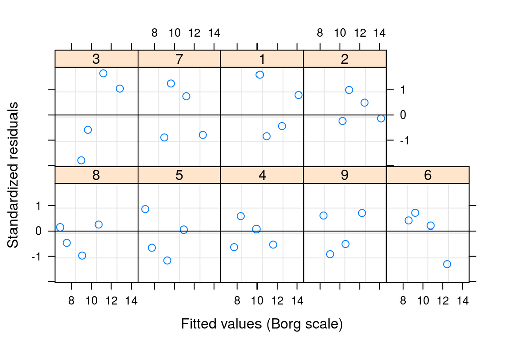

```r
plot(fm1Stool, form = resid(., type = "p") ~ fitted(.) | Subject, abline = 0)
```

## 1.3 Mixed-effects models for replicated, blocked designs

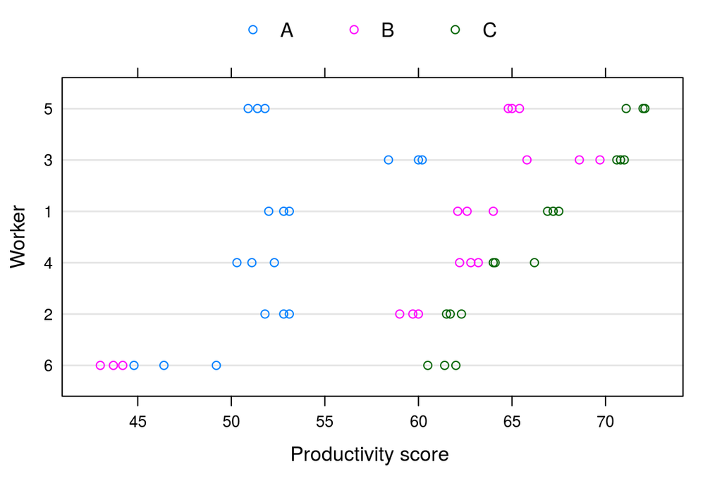

```r
plot(Machines)
```

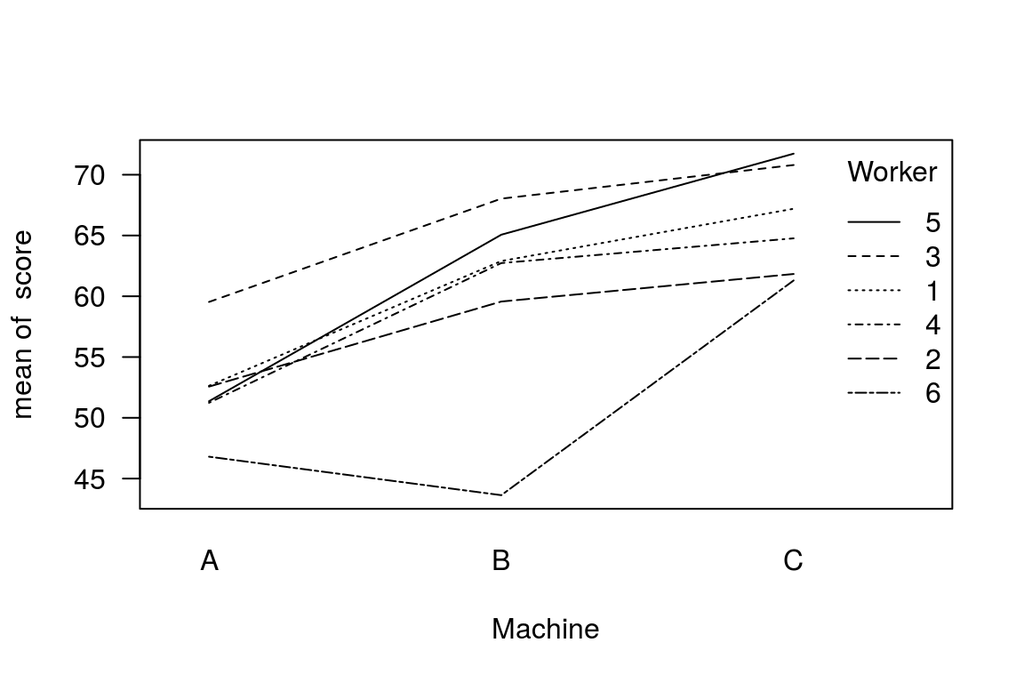

```r
attach(Machines)
interaction.plot(Machine, Worker, score, las = 1)
```

```r
detach()
```

### Fitting random interaction terms

$$y_{ijk} = \beta_{j} + b_{i} + \epsilon_{ijk}, i = 1, ..., 6, j = 1, ..., 3, k = 1, ..., 3,\\
b_{i} ~\sim N(o, \sigma^{2}_{b}), \epsilon_{ijk} \sim N(0, \sigma^{2}) (1.7)$$

This differs from equation 1.6 in that the response ($y$) and the error ($\epsilon$) include an additional counter ($k$) to iterate over the replicates.

```r
fm1Machine <- lme(score ~ Machine, data = Machines, random = ~ 1 | Worker)
summary(fm1Machine)
```

```
## Linear mixed-effects model fit by REML
##  Data: Machines
##        AIC      BIC    logLik
##   296.8782 306.5373 -143.4391
##
## Random effects:
##  Formula: ~1 | Worker
##         (Intercept) Residual
## StdDev:    5.146552 3.161647
##
## Fixed effects: score ~ Machine
##                Value Std.Error DF  t-value p-value
## (Intercept) 52.35556  2.229312 46 23.48507       0
## MachineB     7.96667  1.053883 46  7.55935       0
## MachineC    13.91667  1.053883 46 13.20514       0
##  Correlation:
##          (Intr) MachnB
## MachineB -0.236
## MachineC -0.236  0.500
##
## Standardized Within-Group Residuals:
##        Min         Q1        Med         Q3        Max
## -2.7248806 -0.5232891  0.1327564  0.6513056  1.7559058
##
## Number of Observations: 54
## Number of Groups: 6
```

$$y_{ijk} = \beta_{j} + b_{i} + b_{ij} + \epsilon_{ijk},\\
i = 1, ..., 6,\\
j = 1, ..., 3,\\
k = 1, ..., 3,\\
b_{i} \sim N(0, \sigma^{}_{1}),\\
b_{ij} \sim N(0, \sigma^{2}_{2}),\\
\epsilon_{ijk} \sim N(0, \sigma^{2}).$$

This model includes a random effect for Worker as well as a random effect for Machine within Worker. It can be expressed in R as follows.

```r
fm2Machine <- update(fm1Machine, random = ~ 1 | Worker/Machine )
summary(fm2Machine)
```

```
## Linear mixed-effects model fit by REML
##  Data: Machines
##        AIC      BIC    logLik
##   227.6876 239.2785 -107.8438
##
## Random effects:
##  Formula: ~1 | Worker
##         (Intercept)
## StdDev:     4.78105
##
##  Formula: ~1 | Machine %in% Worker
##         (Intercept)  Residual
## StdDev:    3.729532 0.9615771
##
## Fixed effects: score ~ Machine
##                Value Std.Error DF   t-value p-value
## (Intercept) 52.35556  2.485828 36 21.061613  0.0000
## MachineB     7.96667  2.176972 10  3.659518  0.0044
## MachineC    13.91667  2.176972 10  6.392672  0.0001
##  Correlation:
##          (Intr) MachnB
## MachineB -0.438
## MachineC -0.438  0.500
##
## Standardized Within-Group Residuals:
##         Min          Q1         Med          Q3         Max
## -2.26958675 -0.54846580 -0.01070594  0.43936568  2.54005792
##
## Number of Observations: 54
## Number of Groups:
##              Worker Machine %in% Worker
##                   6                  18
```

```r
anova(fm1Machine, fm2Machine)
```

```
##            Model df      AIC      BIC    logLik   Test  L.Ratio p-value
## fm1Machine     1  5 296.8782 306.5373 -143.4391
## fm2Machine     2  6 227.6876 239.2785 -107.8438 1 vs 2 71.19063  <.0001
```

### 1.3.2 Unbalanced data

```r
# Omit 10 of 54 values.
MachinesUnbal <- Machines[-c(2,3,6,8,9,12,19,20,27,33), ]
table(MachinesUnbal$Machine, MachinesUnbal$Worker)
```

```
##
##     6 2 4 1 3 5
##   A 3 2 2 1 1 3
##   B 3 3 3 1 2 2
##   C 3 3 3 3 3 3
```

```r
fm1MachinesU <- lme( score ~ Machine, data = MachinesUnbal, random = ~ 1 | Worker/Machine)
summary(fm1MachinesU)
```

```
## Linear mixed-effects model fit by REML
##  Data: MachinesUnbal
##        AIC      BIC    logLik
##   193.8715 204.1529 -90.93575
##
## Random effects:
##  Formula: ~1 | Worker
##         (Intercept)
## StdDev:     4.73873
##
##  Formula: ~1 | Machine %in% Worker
##         (Intercept)  Residual
## StdDev:    3.772811 0.9332026
##
## Fixed effects: score ~ Machine
##                Value Std.Error DF   t-value p-value
## (Intercept) 52.35400  2.490612 26 21.020537  0.0000
## MachineB     7.96245  2.214706 10  3.595261  0.0049
## MachineC    13.91822  2.209363 10  6.299653  0.0001
##  Correlation:
##          (Intr) MachnB
## MachineB -0.446
## MachineC -0.447  0.503
##
## Standardized Within-Group Residuals:
##          Min           Q1          Med           Q3          Max
## -2.102312233 -0.499070388 -0.009600115  0.395032252  2.612633808
##
## Number of Observations: 44
## Number of Groups:
##              Worker Machine %in% Worker
##                   6                  18
```

```r
intervals(fm1MachinesU)
```

```
## Approximate 95% confidence intervals
##
##  Fixed effects:
##                 lower      est.    upper
## (Intercept) 47.234474 52.354000 57.47353
## MachineB     3.027773  7.962446 12.89712
## MachineC     8.995454 13.918222 18.84099
## attr(,"label")
## [1] "Fixed effects:"
##
##  Random Effects:
##   Level: Worker
##                    lower    est.    upper
## sd((Intercept)) 2.216293 4.73873 10.13204
##   Level: Machine
##                    lower     est.    upper
## sd((Intercept)) 2.409165 3.772811 5.908316
##
##  Within-group standard error:
##     lower      est.     upper
## 0.7113550 0.9332026 1.2242370
```

Note that you need some level of replication or else this will not work. Make sure to check the intervals to check this phenomenon.

### 1.3.3

## 1.4 An analysis of covariance model

## 1.5 Models for nested classification factors

## 1.6 A split-plot experiment

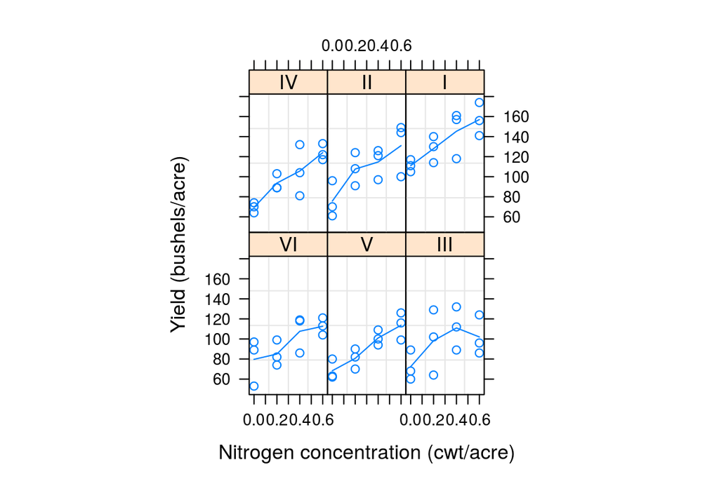

```r
plot(Oats)
```

```r
fm1Oats <- lme(yield ~ ordered(nitro) * Variety, data = Oats, random = ~ 1 | Block/Variety)
anova(fm1Oats)
```

```
##                        numDF denDF   F-value p-value
## (Intercept)                1    45 245.14299  <.0001
## ordered(nitro)             3    45  37.68562  <.0001
## Variety                    2    10   1.48534  0.2724
## ordered(nitro):Variety     6    45   0.30282  0.9322
```

```r
fm2Oats <- update(fm1Oats, yield ~ ordered(nitro) + Variety)
anova(fm2Oats)
```

```
##                numDF denDF   F-value p-value
## (Intercept)        1    51 245.14518  <.0001
## ordered(nitro)     3    51  41.05277  <.0001
## Variety            2    10   1.48534  0.2724
```

```r
summary(fm2Oats)
```

```
## Linear mixed-effects model fit by REML
##  Data: Oats
##       AIC      BIC    logLik
##   587.455 607.1619 -284.7275
##
## Random effects:
##  Formula: ~1 | Block
##         (Intercept)
## StdDev:    14.64488
##
##  Formula: ~1 | Variety %in% Block
##         (Intercept) Residual
## StdDev:    10.47345 12.74987
##
## Fixed effects: yield ~ ordered(nitro) + Variety
##                       Value Std.Error DF   t-value p-value
## (Intercept)       104.50000  7.797492 51 13.401746  0.0000
## ordered(nitro).L   32.94473  3.005172 51 10.962679  0.0000
## ordered(nitro).Q   -5.16667  3.005172 51 -1.719258  0.0916
## ordered(nitro).C   -0.44721  3.005172 51 -0.148815  0.8823
## VarietyMarvellous   5.29167  7.078909 10  0.747526  0.4720
## VarietyVictory     -6.87500  7.078909 10 -0.971195  0.3544
##  Correlation:
##                   (Intr) or().L or().Q or().C VrtyMr
## ordered(nitro).L   0.000
## ordered(nitro).Q   0.000  0.000
## ordered(nitro).C   0.000  0.000  0.000
## VarietyMarvellous -0.454  0.000  0.000  0.000
## VarietyVictory    -0.454  0.000  0.000  0.000  0.500
##
## Standardized Within-Group Residuals:
##         Min          Q1         Med          Q3         Max
## -1.84134149 -0.66279741 -0.06694262  0.63822477  1.66066788
##
## Number of Observations: 72
## Number of Groups:
##              Block Variety %in% Block
##                  6                 18
```

```r
fm3Oats <- update(fm1Oats, yield ~ ordered(nitro))
#anova(fm3Oats)
summary(fm3Oats)
```

```
## Linear mixed-effects model fit by REML
##  Data: Oats
##       AIC      BIC    logLik
##   597.605 613.1416 -291.8025
##
## Random effects:
##  Formula: ~1 | Block
##         (Intercept)
## StdDev:    14.50609
##
##  Formula: ~1 | Variety %in% Block
##         (Intercept) Residual
## StdDev:    11.03871 12.74985
##
## Fixed effects: yield ~ ordered(nitro)
##                      Value Std.Error DF   t-value p-value
## (Intercept)      103.97222  6.640669 51 15.656889  0.0000
## ordered(nitro).L  32.94473  3.005169 51 10.962691  0.0000
## ordered(nitro).Q  -5.16667  3.005169 51 -1.719260  0.0916
## ordered(nitro).C  -0.44721  3.005169 51 -0.148815  0.8823
##  Correlation:
##                  (Intr) or().L or().Q
## ordered(nitro).L 0
## ordered(nitro).Q 0      0
## ordered(nitro).C 0      0      0
##
## Standardized Within-Group Residuals:
##         Min          Q1         Med          Q3         Max
## -1.78155620 -0.61168894  0.02222367  0.62200683  1.68138151
##
## Number of Observations: 72
## Number of Groups:
##              Block Variety %in% Block
##                  6                 18
```

```r
fm4Oats <- lme(yield ~ nitro, data = Oats, random = ~ 1 | Block/Variety)
summary(fm4Oats)
```

```
## Linear mixed-effects model fit by REML
##  Data: Oats
##        AIC      BIC    logLik
##   603.0418 614.2842 -296.5209
##
## Random effects:
##  Formula: ~1 | Block
##         (Intercept)
## StdDev:    14.50598
##
##  Formula: ~1 | Variety %in% Block
##         (Intercept) Residual
## StdDev:    11.00467 12.86696
##
## Fixed effects: yield ~ nitro
##                Value Std.Error DF  t-value p-value
## (Intercept) 81.87222  6.945280 53 11.78818       0
## nitro       73.66667  6.781483 53 10.86291       0
##  Correlation:
##       (Intr)
## nitro -0.293
##
## Standardized Within-Group Residuals:
##         Min          Q1         Med          Q3         Max
## -1.74380777 -0.66475224  0.01710434  0.54298790  1.80298914
##
## Number of Observations: 72
## Number of Groups:
##              Block Variety %in% Block
##                  6                 18
```

```r
VarCorr(fm4Oats)
```

```
##             Variance     StdDev
## Block =     pdLogChol(1)
## (Intercept) 210.4235     14.50598
## Variety =   pdLogChol(1)
## (Intercept) 121.1029     11.00467
## Residual    165.5586     12.86696
```

```r
intervals(fm4Oats)
```

```
## Approximate 95% confidence intervals
##
##  Fixed effects:
##                lower     est.    upper
## (Intercept) 67.94175 81.87222 95.80269
## nitro       60.06473 73.66667 87.26860
## attr(,"label")
## [1] "Fixed effects:"
##
##  Random Effects:
##   Level: Block
##                    lower     est.    upper
## sd((Intercept)) 6.608916 14.50598 31.83934
##   Level: Variety
##                    lower     est.    upper
## sd((Intercept)) 6.408086 11.00467 18.89845
##
##  Within-group standard error:
##    lower     est.    upper
## 10.63652 12.86696 15.56512
```

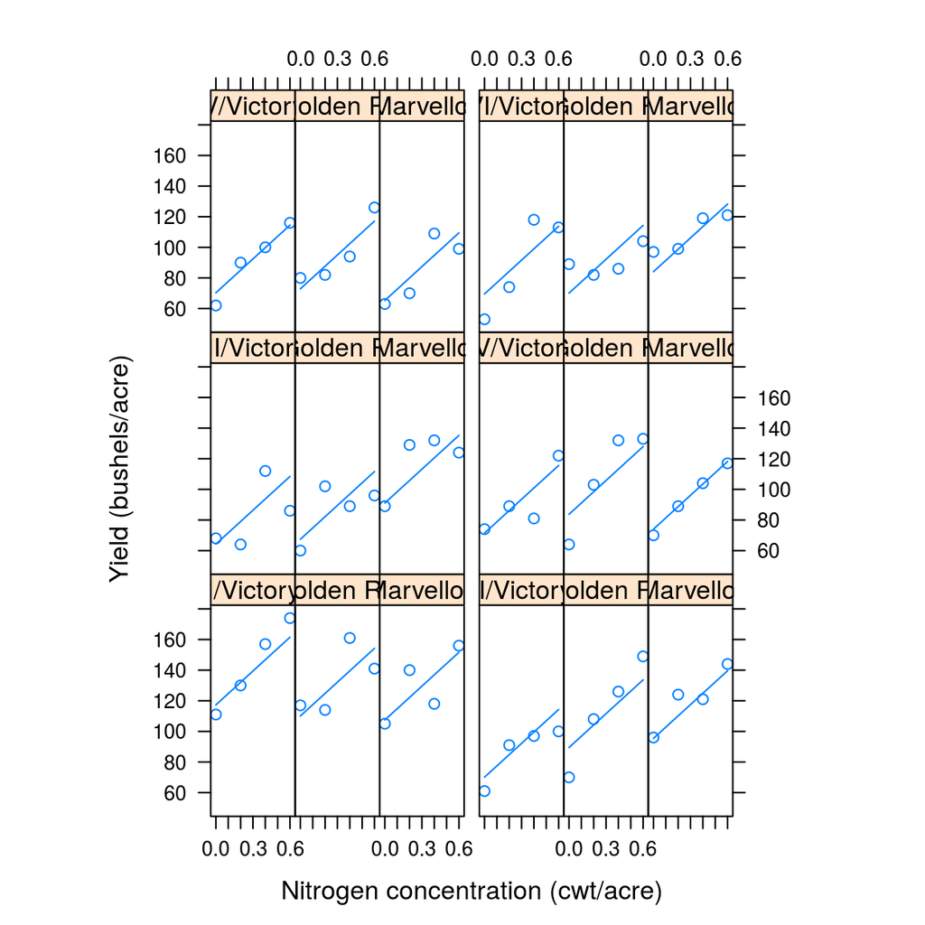

```r
plot(augPred(fm4Oats), aspect = 2.5, layout = c(6,3), between = list(x=c(0,0,0.5)))
```